# Chapter 5

```r
library(tidyverse)
library(cmdstanr)
library(tidybayes)
library(bayesplot)
library(ggthemes)
library(patchwork)
library(easystats)
```

Data analysis workflow 1. Set up purposes: research questions 2. Check data distribution: visualization/check descriptive statistics 3. Imagine data generating mechanism: Relationship between variables/which probability distribution 4. Describe model formula: mathematical formulas 5. Simulate models: Generate the data from the models 6. Implement models: Running Stan 7. Estimate parameters: Running Stan 8. Check models: parameter recovery using simulated data, pp check, convergence check 9. Interpret results: interpret and visualize the results

```r
df <- read_csv("https://raw.githubusercontent.com/MatsuuraKentaro/Bayesian_Statistical_Modeling_with_Stan_R_and_Python/refs/heads/master/chap05/input/data-shopping-1.csv") |>
  mutate(
    Income = Income/100,
    Sex = factor(Sex)
  )
```

### 5.1.1 Set up Purposes

How well Y can be explained by `Sex` and `Income`. Also, how each factor contributes to explaining Y (beta coefficient)

### 5.1.2 Check Data Distribution

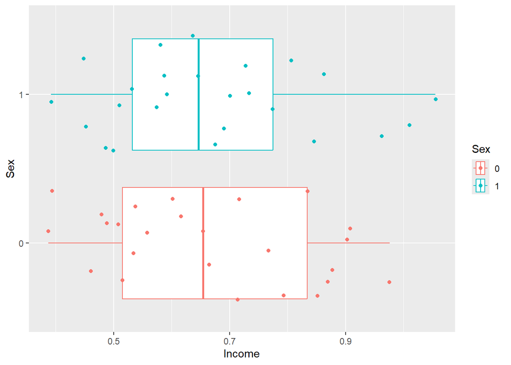

```r
ggplot(df, aes(x = Income, y = Sex, color = Sex)) +
  geom_boxplot() +
  geom_jitter()
```

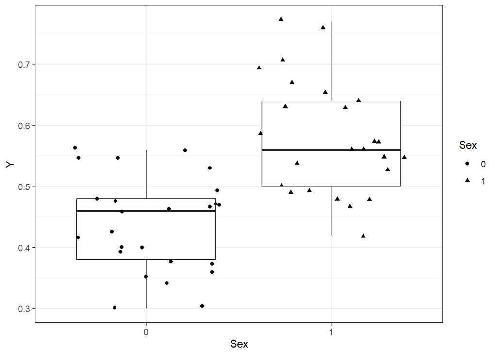

```r
ggplot(df, aes(x = Sex, y = Y)) +
  geom_boxplot() +
  geom_jitter(aes(shape = Sex)) +
  theme_bw()
```

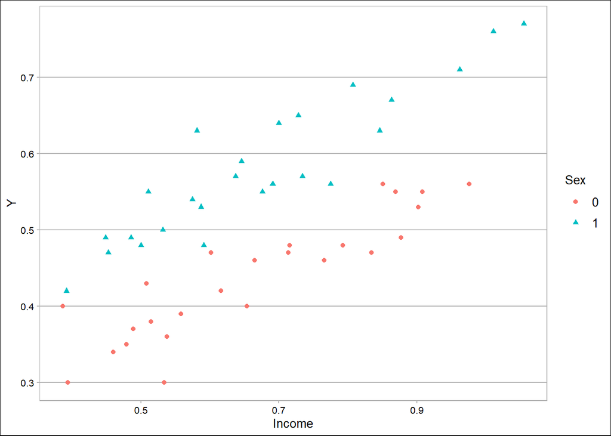

```r
ggplot(df, aes(x = Income, y = Y)) +
  geom_point(aes(shape = Sex, color = Sex)) +
  theme_calc()
```

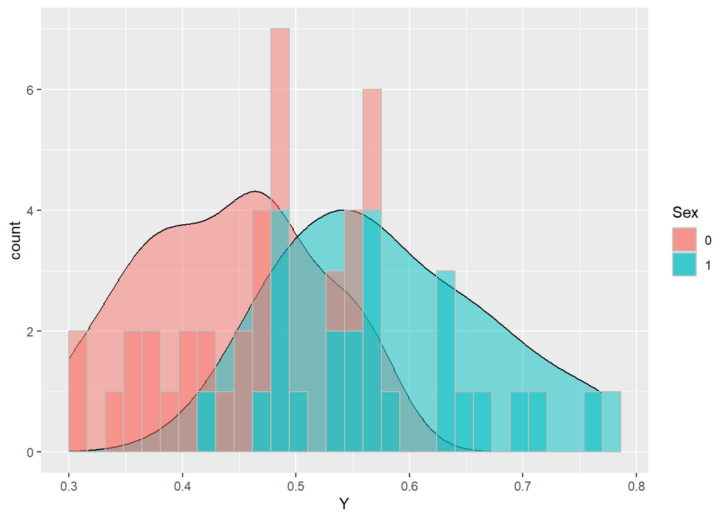

```r
ggplot(df, aes(x = Y, group = Sex)) +
  geom_density(alpha = 0.5, aes(fill = Sex)) +
  geom_histogram(color = "grey", aes(fill = Sex), alpha = 0.5)
```

### 5.1.3 Imagine Data Generating Mechanisms

Y is determined by the linear combination of `Sex` and `Income`

$$Y = b_1 + b_2Sex + b_3Income + \epsilon$$

### 5.1.4 Describe Model Formula

```stan
data {
  int N;
  vector<lower=0, upper=1>[N] Sex;
  vector<lower=0>[N] Income;
  vector<lower = 0, upper=1> [N] Y;
}


parameters { //What MCMC estimates
  vector[3] b; //regression coefficients can be stored as a vector
  real<lower = 0> sigma;
}


//useful when need to use parameters after estimation
//like when sampling from the posterior or for predictive check
transformed parameters {

   vector[N] mu = b[1] + b[2]*Sex[1:N] + b[3]*Income[1:N]; //mu is linear combination of b1:b3, thus can be defined in the transformed parameters. In other words, mu is transformed using parameters defined in the parameters block

}

model {

  Y[1:n] ~ normal(mu[1:n], sigma)

}

//can use any variables before the model blocks
generated quantities {
  array[N] real yp = normal_rng(mu[1:N], sigma)
}
```

### 5.1.6 Estimate Parameters

```r
set.seed(123)

df <- df |>
  mutate(
    Sex = as.numeric(Sex) - 1
    )


N <- nrow(df)

Y_sim_mean <- 0.2 + 0.15*(df$Sex) + 0.4*df$Income

Y_sim <- rnorm(N, Y_sim_mean, sd = 0.1)

df_sim <- list(
  N = N,
  Sex = df$Sex,
  Income = df$Income,
  Y = Y_sim)  #every Y_sim is sampled from different normal distribution with different mean

stan_data <- list(
  N = N,
  Sex = df$Sex,
  Income = df$Income,
  Y = df$Y
)
```

```r
model <- cmdstan_model(stan_file = "model/model5-3.stan")
fit_sim <- model$sample(
  data = df_sim,
  seed = 123,
  parallel_chains = 4,
  refresh = 1000
  )
```

```
Running MCMC with 4 parallel chains...

Chain 1 Iteration:    1 / 2000 [  0%]  (Warmup)
Chain 1 Iteration: 1000 / 2000 [ 50%]  (Warmup)
Chain 1 Iteration: 1001 / 2000 [ 50%]  (Sampling)
Chain 2 Iteration:    1 / 2000 [  0%]  (Warmup)
Chain 2 Iteration: 1000 / 2000 [ 50%]  (Warmup)
Chain 2 Iteration: 1001 / 2000 [ 50%]  (Sampling)
Chain 3 Iteration:    1 / 2000 [  0%]  (Warmup)
Chain 1 Iteration: 2000 / 2000 [100%]  (Sampling)
Chain 1 finished in 0.2 seconds.
Chain 2 Iteration: 2000 / 2000 [100%]  (Sampling)
Chain 2 finished in 0.2 seconds.
Chain 3 Iteration: 1000 / 2000 [ 50%]  (Warmup)
Chain 3 Iteration: 1001 / 2000 [ 50%]  (Sampling)
Chain 3 Iteration: 2000 / 2000 [100%]  (Sampling)
Chain 4 Iteration:    1 / 2000 [  0%]  (Warmup)
Chain 4 Iteration: 1000 / 2000 [ 50%]  (Warmup)
Chain 4 Iteration: 1001 / 2000 [ 50%]  (Sampling)
Chain 4 Iteration: 2000 / 2000 [100%]  (Sampling)
```

[output not shown]

[output not shown]

[output not shown]

[output not shown]

```
Chain 4
```

```
Chain 3 finished in 0.2 seconds.
Chain 4 finished in 0.2 seconds.

All 4 chains finished successfully.
Mean chain execution time: 0.2 seconds.
Total execution time: 0.7 seconds.
```

```r
fit <- model$sample(
  data = stan_data,
  seed = 123,
  parallel_chains = 4,
  refresh = 1000
)
```

```
Running MCMC with 4 parallel chains...

Chain 1 Iteration:    1 / 2000 [  0%]  (Warmup)
Chain 1 Iteration: 1000 / 2000 [ 50%]  (Warmup)
Chain 1 Iteration: 1001 / 2000 [ 50%]  (Sampling)
Chain 2 Iteration:    1 / 2000 [  0%]  (Warmup)
Chain 2 Iteration: 1000 / 2000 [ 50%]  (Warmup)
Chain 2 Iteration: 1001 / 2000 [ 50%]  (Sampling)
```

[output not shown]

[output not shown]

[output not shown]

[output not shown]

```
Chain 2
```

```
Chain 3 Iteration:    1 / 2000 [  0%]  (Warmup)
Chain 3 Iteration: 1000 / 2000 [ 50%]  (Warmup)
Chain 3 Iteration: 1001 / 2000 [ 50%]  (Sampling)
Chain 4 Iteration:    1 / 2000 [  0%]  (Warmup)
```

[output not shown]

[output not shown]

[output not shown]

[output not shown]

```
Chain 4
```

```
Chain 1 Iteration: 2000 / 2000 [100%]  (Sampling)
Chain 1 finished in 0.2 seconds.
Chain 2 Iteration: 2000 / 2000 [100%]  (Sampling)
Chain 3 Iteration: 2000 / 2000 [100%]  (Sampling)
Chain 4 Iteration: 1000 / 2000 [ 50%]  (Warmup)
Chain 4 Iteration: 1001 / 2000 [ 50%]  (Sampling)
Chain 2 finished in 0.2 seconds.
Chain 3 finished in 0.2 seconds.
Chain 4 Iteration: 2000 / 2000 [100%]  (Sampling)
Chain 4 finished in 0.2 seconds.

All 4 chains finished successfully.
Mean chain execution time: 0.2 seconds.
Total execution time: 0.6 seconds.
```

### 5.1.7 Interpret Results

```r
fit
```

```
 variable   mean median   sd  mad     q5    q95 rhat ess_bulk ess_tail
    lp__  135.98 136.30 1.48 1.26 133.09 137.70 1.00     1510     2305
    b[1]    0.15   0.15 0.02 0.02   0.11   0.18 1.00     1776     1937
    b[2]    0.14   0.14 0.01 0.01   0.12   0.15 1.00     2166     1768
    b[3]    0.44   0.44 0.03 0.03   0.38   0.49 1.00     1820     1784
    sigma   0.04   0.04 0.00 0.00   0.03   0.04 1.00     2406     2268
    mu[1]   0.52   0.52 0.01 0.01   0.50   0.54 1.00     2864     2830
    mu[2]   0.57   0.57 0.01 0.01   0.56   0.58 1.00     2879     2948
    mu[3]   0.58   0.58 0.01 0.01   0.56   0.60 1.00     2469     2434
    mu[4]   0.60   0.60 0.01 0.01   0.59   0.62 1.00     2924     3099
    mu[5]   0.51   0.51 0.01 0.01   0.49   0.52 1.00     2380     2612

 # showing 10 of 105 rows (change via 'max_rows' argument or 'cmdstanr_max_rows' option)
```

```r
fit_sim
```

```
 variable  mean median   sd  mad    q5   q95 rhat ess_bulk ess_tail
    lp__  90.16  90.48 1.48 1.26 87.24 91.86 1.00     1669     2372
    b[1]   0.20   0.20 0.06 0.06  0.11  0.29 1.00     1904     1880
    b[2]   0.14   0.14 0.03 0.03  0.09  0.18 1.00     2643     2188
    b[3]   0.42   0.42 0.08 0.07  0.29  0.54 1.00     1908     2111
    sigma  0.10   0.10 0.01 0.01  0.08  0.11 1.00     2149     2179
    mu[1]  0.55   0.55 0.02 0.02  0.51  0.59 1.00     2768     2903
    mu[2]  0.61   0.61 0.02 0.02  0.57  0.64 1.00     3490     3148
    mu[3]  0.60   0.61 0.03 0.03  0.55  0.65 1.00     2404     2656
    mu[4]  0.64   0.64 0.02 0.02  0.61  0.67 1.00     3213     2971
    mu[5]  0.55   0.55 0.02 0.02  0.51  0.59 1.00     2983     2982

 # showing 10 of 105 rows (change via 'max_rows' argument or 'cmdstanr_max_rows' option)
```

### 5.2.1 PP Check

Figure 5.2 right plot

```r
draw_df <- fit |>
  tidy_draws()



tidy_pred <- draw_df |>
  select(
    starts_with("yp")
  )

summary_pred <- tidy_pred |>
  summarise(
    across(
      .cols = everything(),
      .fns = list(
        mean = ~ mean(.x),
        upr = ~ quantile(.x, 0.9),
        lwr = ~ quantile(.x, 0.1)
        ),
      .names = "{.col}_{.fn}"
      )
    ) |>
  pivot_longer(
    cols = everything(),
    names_to = "metric",
    values_to = "value"
  ) |>
  separate(
    col = metric,
    into = c("pred", "metric"),
    sep = "_"
  ) |>
  pivot_wider(
    values_from = "value",
    names_from = "metric"
  )

#equivalent short-cut

draw_df |>
  select(starts_with("yp")) |>
  median_qi(.width = 0.8)
```

```
# A tibble: 1 × 153
  `yp[1]` `yp[1].lower` `yp[1].upper` `yp[2]` `yp[2].lower` `yp[2].upper`
    <dbl>         <dbl>         <dbl>   <dbl>         <dbl>         <dbl>
1   0.519         0.471         0.571   0.570         0.521         0.619
# ℹ 147 more variables: `yp[3]` <dbl>, `yp[3].lower` <dbl>,
#   `yp[3].upper` <dbl>, `yp[4]` <dbl>, `yp[4].lower` <dbl>,
#   `yp[4].upper` <dbl>, `yp[5]` <dbl>, `yp[5].lower` <dbl>,
#   `yp[5].upper` <dbl>, `yp[6]` <dbl>, `yp[6].lower` <dbl>,
#   `yp[6].upper` <dbl>, `yp[7]` <dbl>, `yp[7].lower` <dbl>,
#   `yp[7].upper` <dbl>, `yp[8]` <dbl>, `yp[8].lower` <dbl>,
#   `yp[8].upper` <dbl>, `yp[9]` <dbl>, `yp[9].lower` <dbl>, …
```

```r
df_pred <- df |>
  bind_cols(summary_pred)
```

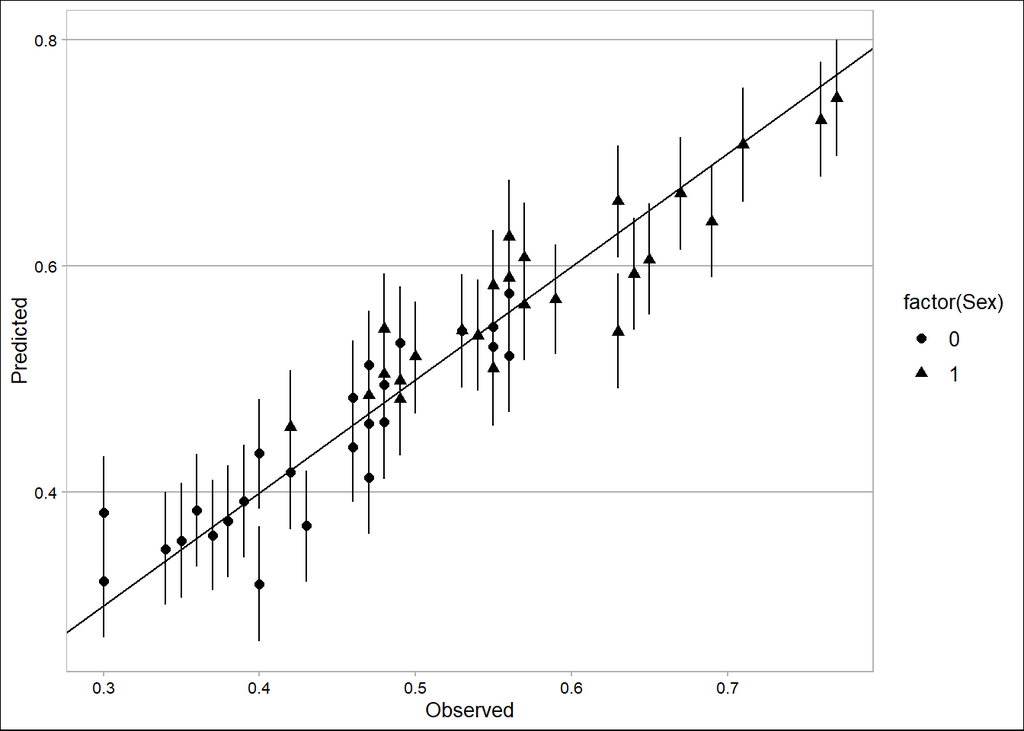

```r
ggplot(df_pred, aes(x = Y, y = mean)) +
  geom_point(aes(shape = factor(Sex)), size = 2) +
  geom_abline(slope = 1) +
  geom_errorbar(aes(ymin = lwr, ymax = upr), width = 0) +
  xlab("Observed") +
  ylab("Predicted") +
  theme_calc()
```

Another way to do PP check

```r
draw_df
```

```
# A tibble: 4,000 × 114
    lp__ `b[1]` `b[2]` `b[3]`  sigma `mu[1]` `mu[2]` `mu[3]` `mu[4]` `mu[5]`
   <dbl>  <dbl>  <dbl>  <dbl>  <dbl>   <dbl>   <dbl>   <dbl>   <dbl>   <dbl>
 1  135.  0.125  0.132  0.490 0.0376   0.542   0.574   0.603   0.614   0.508
 2  134.  0.114  0.126  0.486 0.0344   0.527   0.554   0.588   0.594   0.488
 3  136.  0.123  0.154  0.457 0.0418   0.512   0.572   0.570   0.610   0.511
 4  135.  0.111  0.144  0.485 0.0439   0.523   0.568   0.584   0.608   0.502
 5  137.  0.130  0.136  0.470 0.0339   0.529   0.569   0.588   0.607   0.505
 6  137.  0.136  0.151  0.451 0.0389   0.520   0.578   0.576   0.615   0.517
 7  137.  0.143  0.150  0.440 0.0396   0.517   0.577   0.572   0.613   0.518
 8  135.  0.158  0.138  0.441 0.0373   0.534   0.581   0.589   0.617   0.521
 9  136.  0.162  0.137  0.426 0.0439   0.524   0.574   0.578   0.609   0.517
10  132.  0.147  0.116  0.436 0.0441   0.518   0.544   0.572   0.580   0.485
# ℹ 3,990 more rows
# ℹ 104 more variables: `mu[6]` <dbl>, `mu[7]` <dbl>, `mu[8]` <dbl>,
#   `mu[9]` <dbl>, `mu[10]` <dbl>, `mu[11]` <dbl>, `mu[12]` <dbl>,
#   `mu[13]` <dbl>, `mu[14]` <dbl>, `mu[15]` <dbl>, `mu[16]` <dbl>,
#   `mu[17]` <dbl>, `mu[18]` <dbl>, `mu[19]` <dbl>, `mu[20]` <dbl>,
#   `mu[21]` <dbl>, `mu[22]` <dbl>, `mu[23]` <dbl>, `mu[24]` <dbl>,
#   `mu[25]` <dbl>, `mu[26]` <dbl>, `mu[27]` <dbl>, `mu[28]` <dbl>, …
```

```r
fit$draws(format = "df")
```

```
# A draws_df: 1000 iterations, 4 chains, and 105 variables
   lp__ b[1] b[2] b[3] sigma mu[1] mu[2] mu[3]
1   135 0.13 0.13 0.49 0.038  0.54  0.57  0.60
2   134 0.11 0.13 0.49 0.034  0.53  0.55  0.59
3   136 0.12 0.15 0.46 0.042  0.51  0.57  0.57
4   135 0.11 0.14 0.48 0.044  0.52  0.57  0.58
5   137 0.13 0.14 0.47 0.034  0.53  0.57  0.59
6   137 0.14 0.15 0.45 0.039  0.52  0.58  0.58
7   137 0.14 0.15 0.44 0.040  0.52  0.58  0.57
8   135 0.16 0.14 0.44 0.037  0.53  0.58  0.59
9   136 0.16 0.14 0.43 0.044  0.52  0.57  0.58
10  132 0.15 0.12 0.44 0.044  0.52  0.54  0.57
# ... with 3990 more draws, and 97 more variables
# ... hidden reserved variables {'.chain', '.iteration', '.draw'}
```

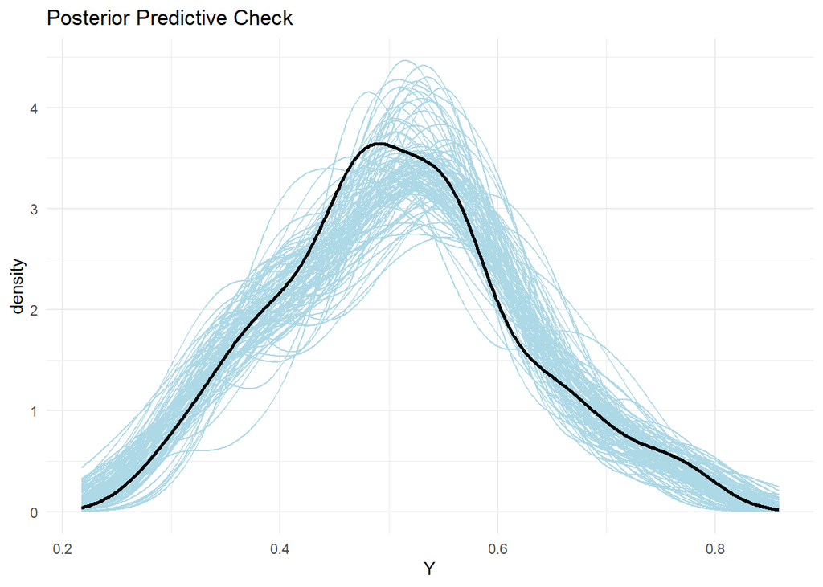

```r
pp_data <- fit |>
  spread_draws(yp[i]) |>
  filter(.draw <= 100) # Subset for performance

ggplot(pp_data, aes(x = yp, group = .draw)) + #.draw indicates joint distribution.
  geom_density(color = "lightblue", alpha = 0.5, linewidth = 0.5) +
  geom_density(data = tibble(Y = stan_data$Y), aes(x = Y), inherit.aes = FALSE, linewidth = 1) +
  theme_minimal() +
  labs(title = "Posterior Predictive Check", x = "Y")
```

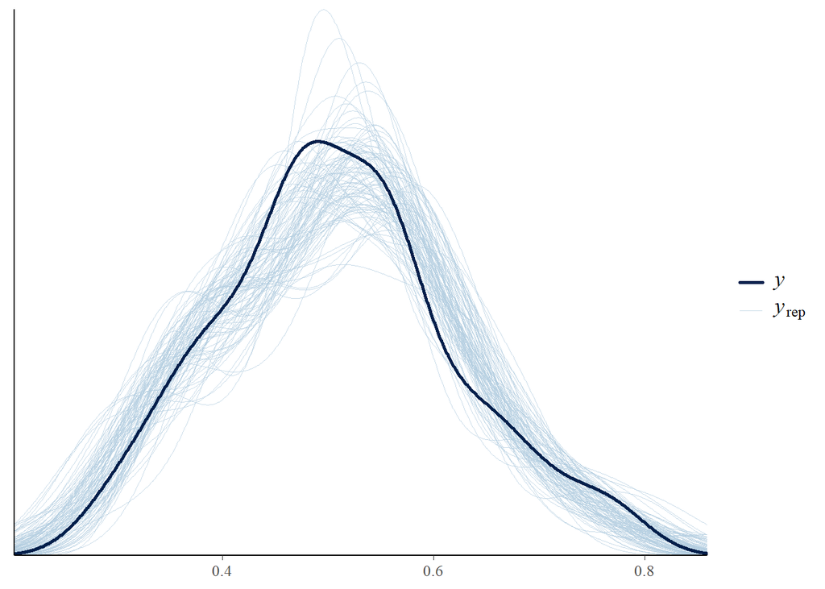

```r
#short-cut

yrep <- fit$draws(variables = "yp", format = "draws_matrix")

indice <- sample(nrow(yrep), 100)
yrep_small <- yrep[indice, ]

ppc_dens_overlay(
  y = stan_data$Y,
  yrep = yrep_small
)
```

### 5.2.2 Posterior Residual Check

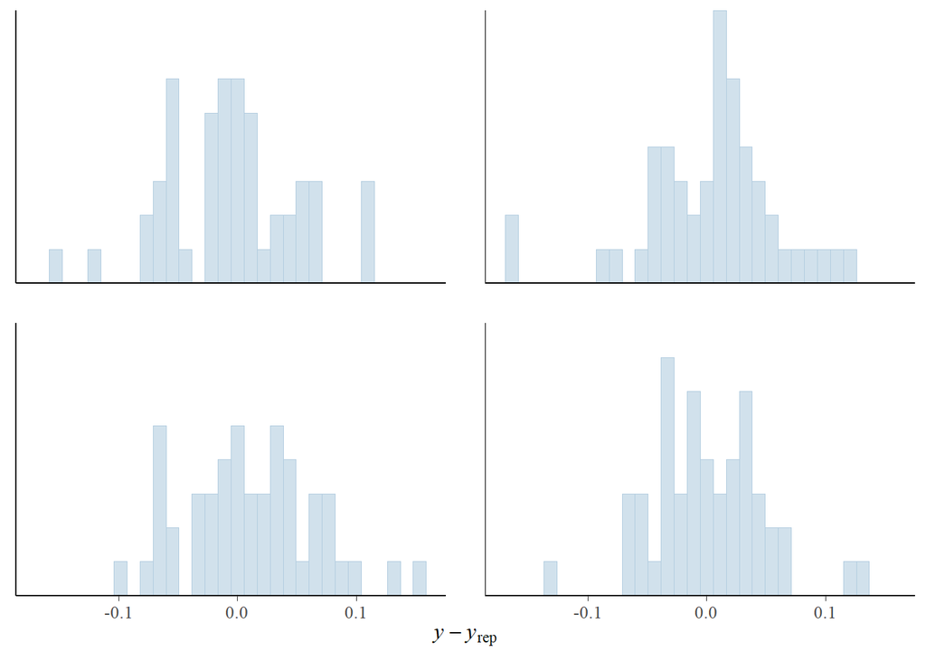

```r
ppc_error_hist(
  y = stan_data$Y,
  yrep = yrep[1:4, ]
  )
```

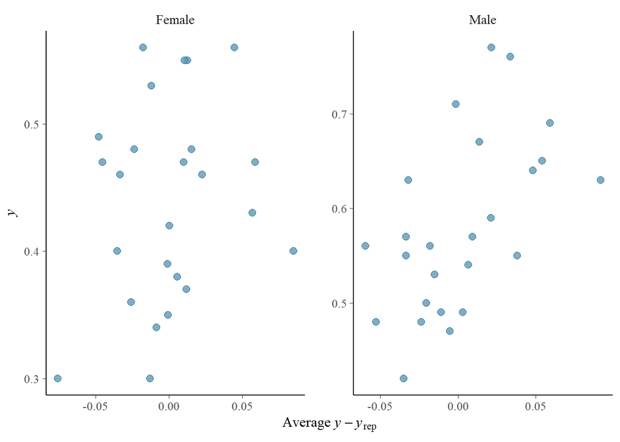

```r
ppc_error_scatter_avg_grouped(
  y = stan_data$Y,
  yrep = yrep[1:50, ],
  group = factor(stan_data$Sex, labels = c("Female", "Male"))
)
```

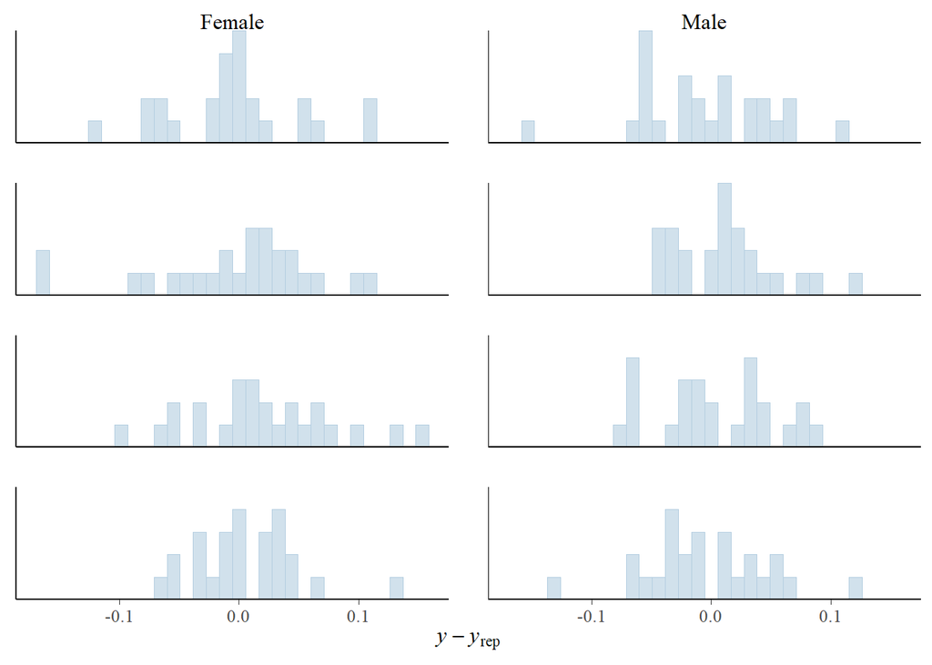

```r
ppc_error_hist_grouped(
  y = stan_data$Y,
  yrep[1:4, ],
  group = factor(stan_data$Sex, labels = c("Female", "Male"))
  )
```

### 5.2.3 Scatterplot Matrix of MCMC Sample

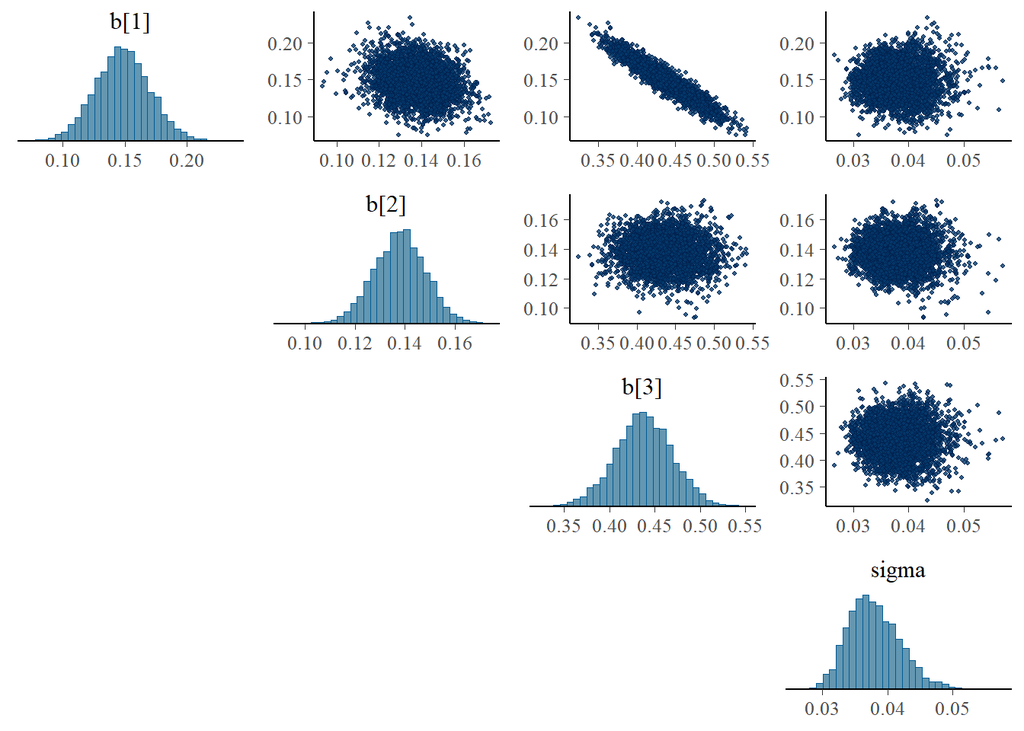

```r
draw_mcmc <- fit$draws(format = "data.frame") |>
  select(starts_with("b"), "sigma")
mcmc_pairs(
  draw_mcmc,
  off_diag_args = list(size = 0.75)
  )
```

### Short-cut using Bayesplot

1. PP check

posterior predictive check - density plot

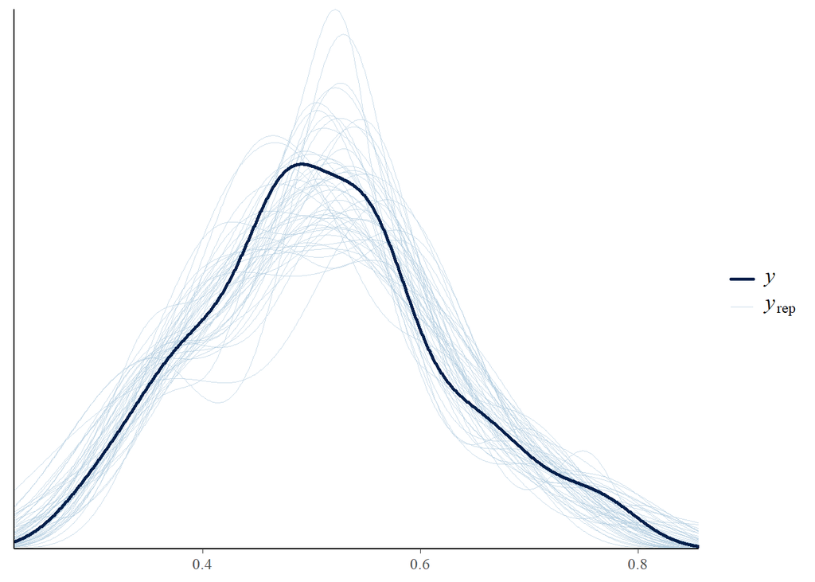

```r
#in order to use ppc plot, yrep must be matrix
pp_draw <- fit$draws(format = "draws_matrix", variables = "yp")

#using only subset
yrep <- pp_draw[sample(nrow(pp_draw), 50), ]

ppc_dens_overlay(
  y = stan_data$Y,
  yrep = yrep
  )
```

posterior predictive check - interval plot

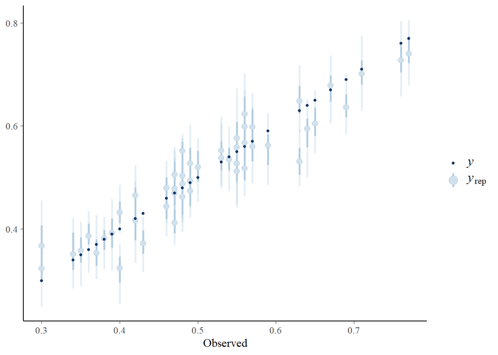

```r
ppc_intervals(
  y = stan_data$Y,
  yrep = yrep,
  x = stan_data$Y
) +
  xlab("Observed")
```

posterior residual check

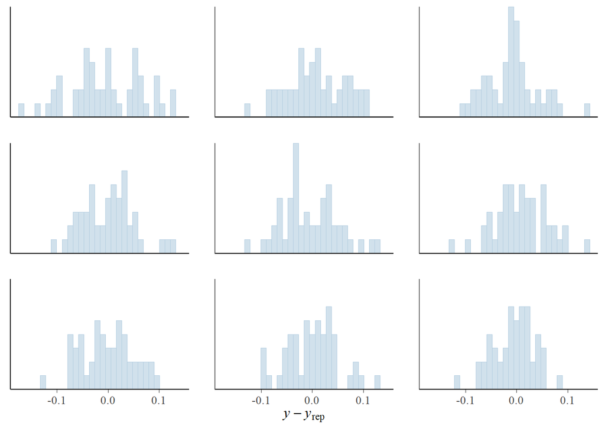

```r
ppc_error_hist(
  y = stan_data$Y,
  yrep = yrep[1:9, ]
)
```

2. Scatter plot matrix

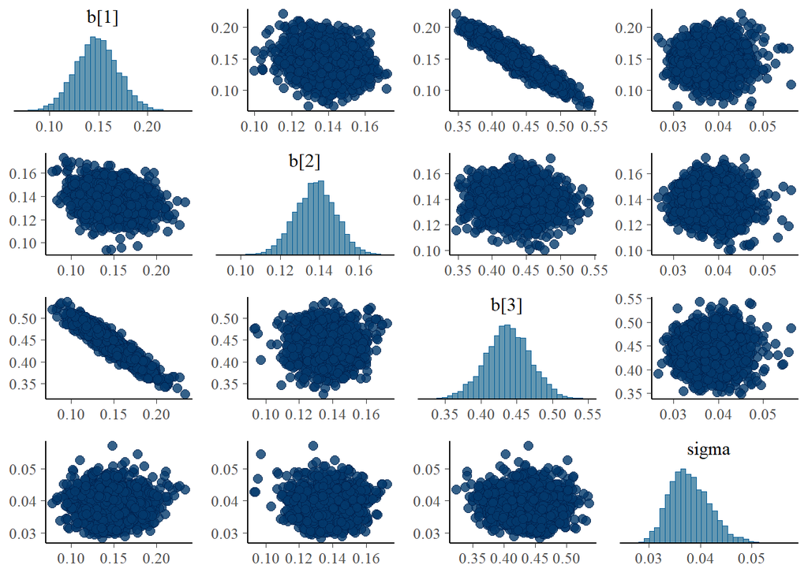

```r
mcmc_pairs(
  x = fit$draws(variables = c("b", "sigma"))
)
```

## 5.3 Binomial Logistic Regression

```r
df <- read_csv("https://raw.githubusercontent.com/MatsuuraKentaro/Bayesian_Statistical_Modeling_with_Stan_R_and_Python/refs/heads/master/chap05/input/data-shopping-2.csv") |>
  mutate(
    proportion = Y/M #proportion of purchasing by N of visit
  )
```

### 5.3.3 Imagine Data Generating Mechanisms

proportion can’t be negative and can’t be above 1. In this case, need to transform the linear combination of variables reflecting this range. One of the options is to use `inv_logit` Also, the noise should b3e discrete than continuous because proportion is essentially discrete variable (e.g., how many times I purchased for 10 visits).

### 5.3.4 Describe Model Formula

$$\begin{aligned}
q[n] = inv_logit(b_1 + b_2Sex[n] + b_3Income[n]) \\
Y[n] \sim Binomial(M[n], q[n])
\end{aligned}$$
`M[n]` represents the total number of visit for each customer. `n` represents the index of each customer. `q[n]` represents probability of purchasing. Thus, here we model the number of purchasing in a sequence of independent visits.

### 5.3.5 Implement the model

```stan
data {
  int N;
  vector<lower=0, upper=1>[N] Sex;
  vector<lower=0>[N] Income;
  array[N] int<lower=0> M;
  array[N] int<lower=0> Y;

}

parameters {
  vector[3] real b;
}

transformed parameters {
  vector[N] q = inv_logit(b[1] + b[2]*Sex[1:N] + b[3]*Income[1:N]);
}

model {
  Y[1:N] ~ binomial(M[1:N], q[1:N]); //M[n] is an observed variable
}

generated quantities {
  array[N] int yp = binomial_rng(M[1:N], q[1:N]);
}
```

In stan, vector can only store real numbers. Thus, for integers, need to use array

```r
model_5.4 <- cmdstan_model("model/model5-4.stan")
```

```r
stan_data <- list(
  N = nrow(df),
  Sex = df$Sex,
  Income = df$Income,
  M = df$M,
  Y = df$Y
)
```

```r
fit <- model_5.4$sample(
  data = stan_data,
  seed = 123,
  refresh = 1000,
  chains = 4,
  parallel_chains = 4
)
```

```
Running MCMC with 4 parallel chains...
```

[output not shown]

[output not shown]

[output not shown]

```
Chain 1 Iteration:    1 / 2000 [  0%]  (Warmup)
```

[output not shown]

[output not shown]

[output not shown]

[output not shown]

[output not shown]

[output not shown]

```
Chain 2 Iteration:    1 / 2000 [  0%]  (Warmup)
```

[output not shown]

[output not shown]

[output not shown]

[output not shown]

[output not shown]

[output not shown]

[output not shown]

[output not shown]

[output not shown]

```
Chain 3 Iteration:    1 / 2000 [  0%]  (Warmup)
Chain 4 Iteration:    1 / 2000 [  0%]  (Warmup)
Chain 1 Iteration: 1000 / 2000 [ 50%]  (Warmup)
Chain 2 Iteration: 1000 / 2000 [ 50%]  (Warmup)
Chain 1 Iteration: 1001 / 2000 [ 50%]  (Sampling)
Chain 2 Iteration: 1001 / 2000 [ 50%]  (Sampling)
Chain 3 Iteration: 1000 / 2000 [ 50%]  (Warmup)
Chain 4 Iteration: 1000 / 2000 [ 50%]  (Warmup)
Chain 1 Iteration: 2000 / 2000 [100%]  (Sampling)
Chain 3 Iteration: 1001 / 2000 [ 50%]  (Sampling)
Chain 4 Iteration: 1001 / 2000 [ 50%]  (Sampling)
Chain 1 finished in 0.7 seconds.
Chain 2 Iteration: 2000 / 2000 [100%]  (Sampling)
Chain 3 Iteration: 2000 / 2000 [100%]  (Sampling)
Chain 2 finished in 0.7 seconds.
Chain 3 finished in 0.7 seconds.
Chain 4 Iteration: 2000 / 2000 [100%]  (Sampling)
Chain 4 finished in 0.7 seconds.

All 4 chains finished successfully.
Mean chain execution time: 0.7 seconds.
Total execution time: 1.1 seconds.
```

```r
fit$summary()
```

```
# A tibble: 104 × 10
   variable      mean    median      sd     mad       q5      q95  rhat ess_bulk
   <chr>        <dbl>     <dbl>   <dbl>   <dbl>    <dbl>    <dbl> <dbl>    <dbl>
 1 lp__     -298.     -298.     1.22    1.01    -3.00e+2 -2.97e+2  1.00    1361.
 2 b[1]       -1.49     -1.48   0.399   0.392   -2.17e+0 -8.58e-1  1.00    1467.
 3 b[2]        0.0982    0.104  0.203   0.207   -2.34e-1  4.24e-1  1.00    1939.
 4 b[3]        0.0159    0.0157 0.00567 0.00562  6.76e-3  2.57e-2  1.00    1555.
 5 q[1]        0.467     0.467  0.0472  0.0489   3.88e-1  5.43e-1  1.00    2273.
 6 q[2]        0.411     0.411  0.0306  0.0302   3.60e-1  4.62e-1  1.00    2767.
 7 q[3]        0.516     0.517  0.0592  0.0610   4.17e-1  6.12e-1  1.00    2056.
 8 q[4]        0.443     0.443  0.0312  0.0314   3.91e-1  4.93e-1  1.00    3089.
 9 q[5]        0.361     0.360  0.0365  0.0363   3.00e-1  4.22e-1  1.00    2047.
10 q[6]        0.474     0.474  0.0488  0.0505   3.92e-1  5.53e-1  1.00    2237.
# ℹ 94 more rows
# ℹ 1 more variable: ess_tail <dbl>
```

```r
fit$draws(
  variables ="b"
  ) |>
  model_parameters(exponentiate = TRUE) #get odds-ratio
```

```
# Fixed Effects

Parameter | Median |       95% CI |     pd
------------------------------------------
b[1]      |   0.23 | [0.10, 0.48] |   100%
b[2]      |   1.11 | [0.75, 1.64] | 68.20%
b[3]      |   1.02 | [1.01, 1.03] | 99.88%
```

```
Uncertainty intervals (equal-tailed) computed using a MCMC distribution
  approximation.
```

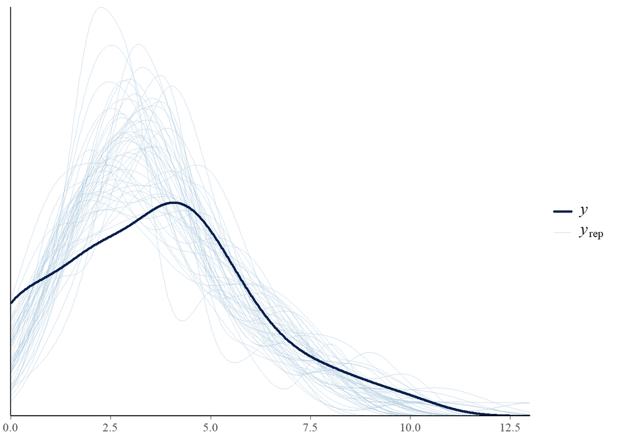

```r
yrep <- fit$draws(
  variables = "yp",
  format = "draws_matrix"
)

ppc_dens_overlay(
  y = stan_data$Y,
  yrep = yrep[1:50, ]
)
```

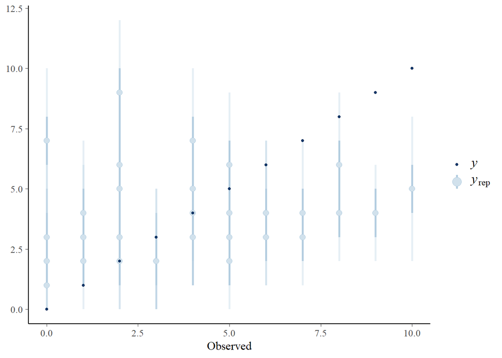

```r
ppc_intervals(
  y = stan_data$Y,
  yrep = yrep,
  x = stan_data$Y
) +
  xlab("Observed")
```

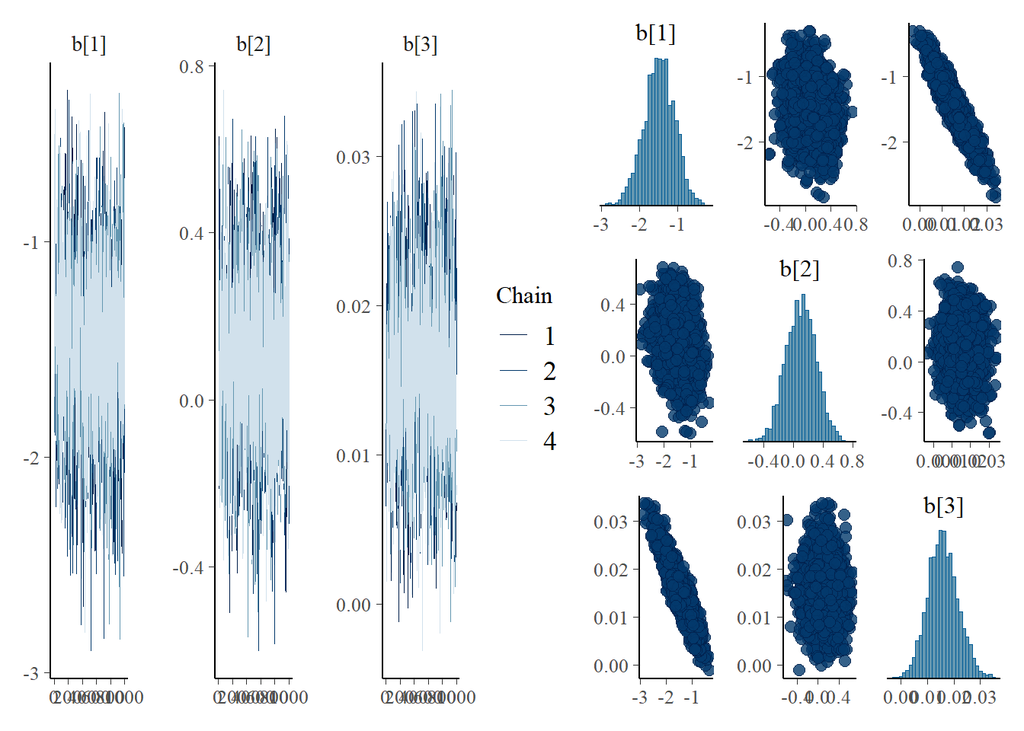

```r
trace <- mcmc_trace(fit$draws(variables = "b"))
pairs <- mcmc_pairs(fit$draws(variables = "b"))

trace | pairs
```

### 5.4 Logistic Regression

```r
df <- read_csv("https://raw.githubusercontent.com/MatsuuraKentaro/Bayesian_Statistical_Modeling_with_Stan_R_and_Python/refs/heads/master/chap05/input/data-shopping-3.csv")
```

### 5.4.1 Set up Purposes

How Sex, Income, Discount can predict Y and how much each of them contributes to the purchase probability.

### 5.4.2 Check Data Distribution

When variables are binary, bar plot filled with explanatory variable is more useful

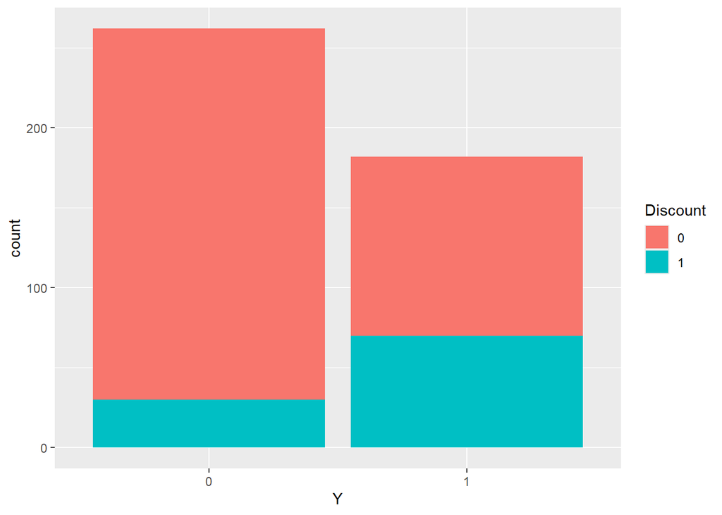

```r
ggplot(df |> mutate(Y = factor(Y), Discount = factor(Discount)),
       aes(x = Y, fill = Discount)) +
  geom_bar()
```

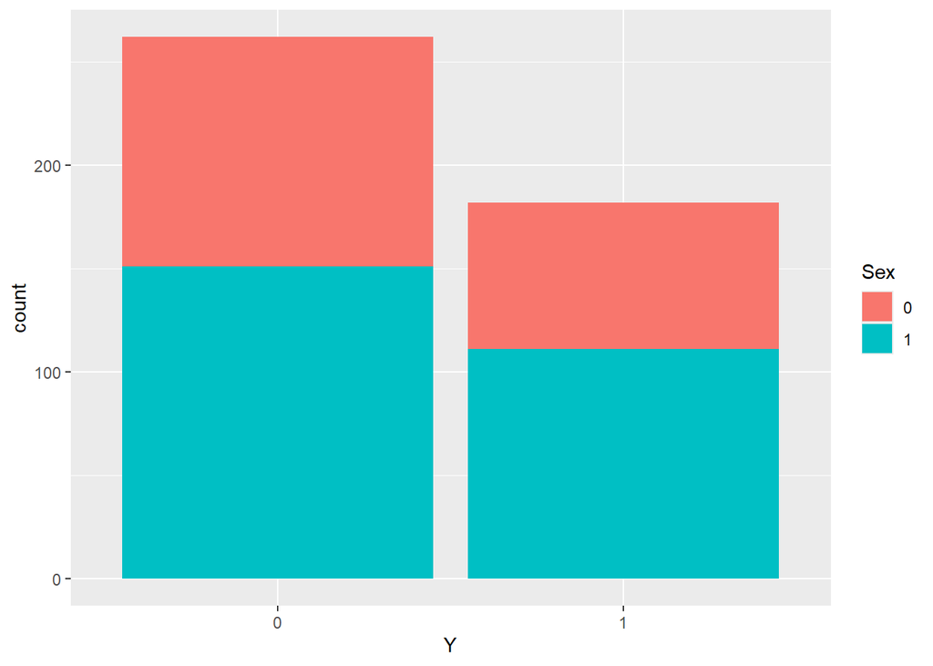

```r
ggplot(df |> mutate(Y = factor(Y), Sex = factor(Sex)),
       aes(x = Y, fill = Sex)) +
  geom_bar()
```

### 5.4.3 Imagine Data Generating Mechanisms

Binomial distribution is a probability distribution for a series of event (count) given a fixed probability for each event happened. Bernoulli distribution is for a single event. When n = 1 in Binomial distribution, it becomes Bernoulli distribution. Here, the response variable is a single event (yes or no), we can use Bernoulli distribution.

### 5.4.4 Describe Model Formula

$$\begin{aligned}
& q[v] = invlogit(b_1 + b_2Sex[v] + b_3Income[v] + b_4Discount[v] ) && v = 1,...,V \\
& Y[v] \sim Bernoulli(q[v]) && v = 1,...,V
\end{aligned}$$

Here, we indexed by v not n because this model is for each visit. Also, in this model, we didn’t account for the repeated measure of the data (i.e., each individual has multiple observations thus each observation is not independent). This can be addressed using hierarchical model later.

### 5.4.5 Implement Models

```r
stan_data <- list(
  V = nrow(df),
  Sex = df$Sex,
  Income = df$Income,
  Discount = df$Discount,
  Y = df$Y
)
```

```stan
data {
  int V;
  vector<lower=0, upper=1>[V] Sex;
  vector<lower=0>[V] Income;
  vector<lower=0, upper=1>[V] Discount;
  array[V] int <lower=0, upper=1> Y;
}

parameters {
  vector[4] b;
}

transformed parameters {
  vector[V] q = inv_logit(
  b[1] + b[2]*Sex[1:V] + b[3]*Income[1:V] + b[4]*Discount[1:V]
  );
}

model {
  Y[1:V] ~ bernoulli(q[1:V]);
}

generated quantities {
  array[V] int yp = bernoulli_rng(q[1:V]);
}
```

If we are not interested in probability of each visit, then we can write as below

```stan
data {
  int V;
  vector<lower=0, upper=1>[V] Sex;
  vector<lower=0>[V] Income;
  vector<lower=0, upper=1>[V] Discount;
  array[V] int <lower=0, upper=1> Y;
}

parameters {
  vector[4] b;
}

model {
  Y[1:V] ~ bernoulli_logit(
    b[1] + b[2]*Sex[1:V] + b[3]*Income[1:V] + b[4]*Discount[1:V]
    );
}

generated quantities {
  array[V] int yp = bernoulli_logit_rng(
    b[1] + b[2]*Sex[1:V] + b[3]*Income[1:V] + b[4]*Discount[1:V]
    );
}
```

```r
model5.5 <- cmdstan_model("model/model5-5.stan")
```

```r
fit_5.5 <- model5.5$sample(
  data = stan_data,
  seed = 123,
  parallel_chains = 4,
  refresh = 1000
)
```

```
Running MCMC with 4 parallel chains...
```

[output not shown]

[output not shown]

[output not shown]

```
Chain 1 Iteration:    1 / 2000 [  0%]  (Warmup)
```

[output not shown]

[output not shown]

[output not shown]

[output not shown]

[output not shown]

[output not shown]

```
Chain 2 Iteration:    1 / 2000 [  0%]  (Warmup)
```

[output not shown]

[output not shown]

[output not shown]

[output not shown]

[output not shown]

[output not shown]

```
Chain 3 Iteration:    1 / 2000 [  0%]  (Warmup)
Chain 4 Iteration:    1 / 2000 [  0%]  (Warmup)
Chain 1 Iteration: 1000 / 2000 [ 50%]  (Warmup)
Chain 1 Iteration: 1001 / 2000 [ 50%]  (Sampling)
Chain 2 Iteration: 1000 / 2000 [ 50%]  (Warmup)
Chain 3 Iteration: 1000 / 2000 [ 50%]  (Warmup)
Chain 4 Iteration: 1000 / 2000 [ 50%]  (Warmup)
Chain 2 Iteration: 1001 / 2000 [ 50%]  (Sampling)
Chain 3 Iteration: 1001 / 2000 [ 50%]  (Sampling)
Chain 4 Iteration: 1001 / 2000 [ 50%]  (Sampling)
Chain 1 Iteration: 2000 / 2000 [100%]  (Sampling)
Chain 2 Iteration: 2000 / 2000 [100%]  (Sampling)
Chain 1 finished in 5.0 seconds.
Chain 2 finished in 5.0 seconds.
Chain 4 Iteration: 2000 / 2000 [100%]  (Sampling)
Chain 4 finished in 5.1 seconds.
Chain 3 Iteration: 2000 / 2000 [100%]  (Sampling)
Chain 3 finished in 5.2 seconds.

All 4 chains finished successfully.
Mean chain execution time: 5.1 seconds.
Total execution time: 5.6 seconds.
```

```r
fit_5.5$summary()
```

```
# A tibble: 893 × 10
   variable      mean    median      sd     mad       q5      q95  rhat ess_bulk
   <chr>        <dbl>     <dbl>   <dbl>   <dbl>    <dbl>    <dbl> <dbl>    <dbl>
 1 lp__     -275.     -275.     1.49    1.21    -2.78e+2 -2.74e+2  1.01    1606.
 2 b[1]       -2.01     -2.01   0.438   0.449   -2.73e+0 -1.31e+0  1.00    1815.
 3 b[2]        0.267     0.264  0.219   0.221   -8.65e-2  6.30e-1  1.00    2483.
 4 b[3]        0.0166    0.0166 0.00603 0.00610  6.85e-3  2.62e-2  1.00    1811.
 5 b[4]        1.66      1.66   0.249   0.249    1.26e+0  2.08e+0  1.00    2518.
 6 q[1]        0.355     0.355  0.0492  0.0489   2.75e-1  4.37e-1  1.00    2709.
 7 q[2]        0.739     0.742  0.0518  0.0528   6.50e-1  8.19e-1  1.00    2964.
 8 q[3]        0.355     0.355  0.0492  0.0489   2.75e-1  4.37e-1  1.00    2709.
 9 q[4]        0.355     0.355  0.0492  0.0489   2.75e-1  4.37e-1  1.00    2709.
10 q[5]        0.739     0.742  0.0518  0.0528   6.50e-1  8.19e-1  1.00    2964.
# ℹ 883 more rows
# ℹ 1 more variable: ess_tail <dbl>
```

```r
fit_5.5$draws(
  variables = "b"
  ) |>
  model_parameters(exponentiate = TRUE)
```

```
# Fixed Effects

Parameter | Median |       95% CI |     pd
------------------------------------------
b[1]      |   0.13 | [0.06, 0.31] |   100%
b[2]      |   1.30 | [0.86, 2.03] | 88.75%
b[3]      |   1.02 | [1.00, 1.03] | 99.40%
b[4]      |   5.26 | [3.28, 8.58] |   100%
```

```
Uncertainty intervals (equal-tailed) computed using a MCMC distribution
  approximation.
```

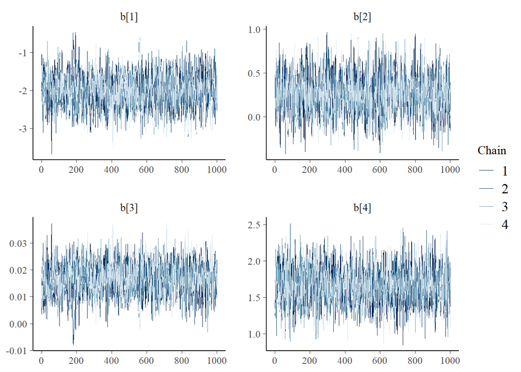

```r
fit_5.5$draws(
  variables = "b"
  ) |> mcmc_trace()
```

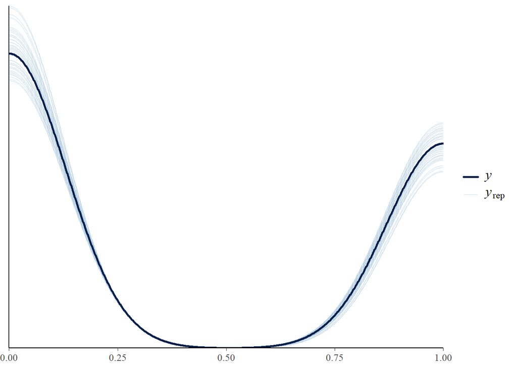

```r
yrep <- fit_5.5$draws(
  variables = "yp",
  format = "draws_matrix"
)[sample(nrow(df), 50), ]

ppc_dens_overlay( #check if data fits into Bernoulli distribution
  y = stan_data$Y,
  yrep = yrep
)
```

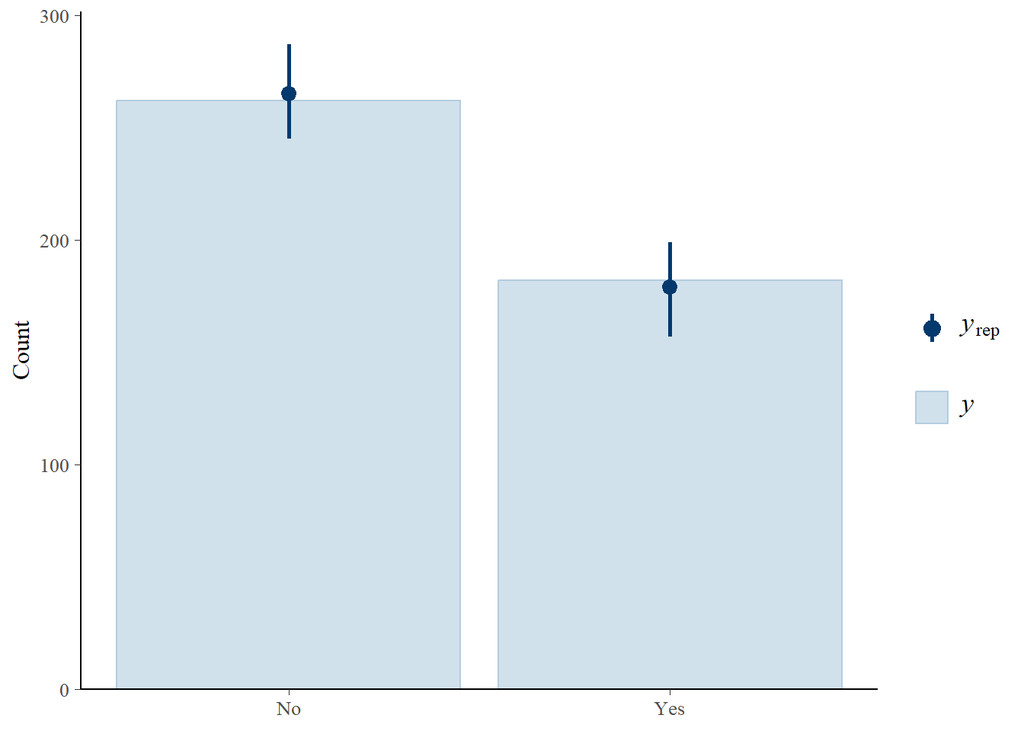

```r
ppc_bars( #for discrete response variable, ppc_bars is the right tool for pp check
  y = stan_data$Y,
  yrep = yrep
) +
  scale_x_continuous(
    breaks = c(0, 1),
    labels = c("No", "Yes")
  )
```

ROC curve - without uncertainty

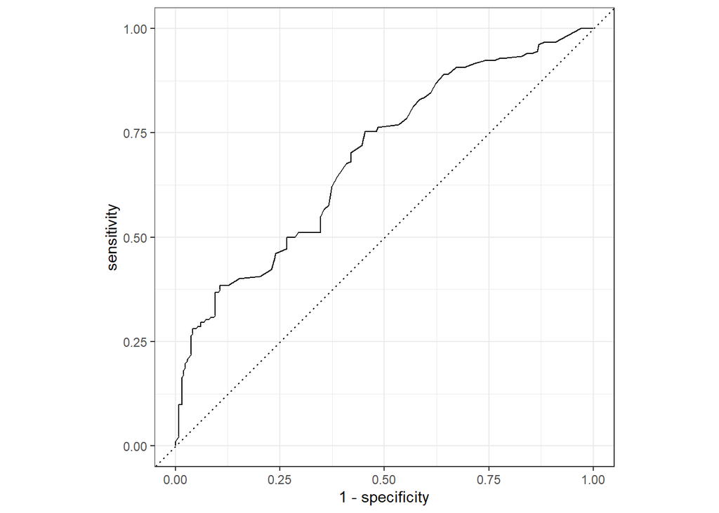

```r
prob_est <- fit_5.5$summary(
  variables = "q"
) |>
  select(median) |>
  unlist()

df_pred <- df |>
  mutate(
    prob = prob_est,
    observed = factor(Y, levels = c("1", "0"))
  )

roc_data <- df_pred |>
  yardstick::roc_curve(truth = observed, prob)

autoplot(roc_data)
```

### 5.5 Poisson Regression

Assumption: time intervals from an event happened to the next event happened are independently generated from an exponential distribution. In other words, timing of visit A does not impact on the next visit. Also, it assumes that mean and the variance are equal.

### 5.5.2 Describe Model Formula

$$\begin{aligned}
&\log\lambda[n] = b_1 + b_2Sex[n] + b_3Income[n] \\
&\lambda[n] = \text{exp}(b_1 + b_2Sex[n] + b_3Income[n]) && n = 1,...,N \\
&M[n] \sim \text{Poission}(\lambda[n]) && n = 1,...,N
\end{aligned}$$

### 5.5.3 Implement the Model

```stan
data {
  int N;
  vector<lower=0,upper=1>[N] Sex;
  vector<lower=0>[N] Income;
  array[N] int<lower=0> M;
}

parameters {
  vector[3] b;
}

transformed parameters {
  vector[N] log_lambda = (b[1] + b[2]*Sex[1:N] + b[3]*Income[1:N]);
}

model {
  M[1:N] ~ poisson_log(log_lambda[1:N]); //use log link function to estimate lambda then we don't have to calculate exp(eta)
}

generated quantities {
  array[N] int mp = poisson_log_rng(log_lambda[1:N]);
}
```

```r
df <- read_csv("https://raw.githubusercontent.com/MatsuuraKentaro/Bayesian_Statistical_Modeling_with_Stan_R_and_Python/refs/heads/master/chap05/input/data-shopping-2.csv")
stan_data <- list(
  N = nrow(df),
  Sex = df$Sex,
  Income = df$Income,
  M = df$M
)
```

```r
model5.6 <- cmdstan_model("model/model5-6.stan")
```

```r
fit_5.6 <- model5.6$sample(
  data = stan_data,
  seed = 123,
  refresh = 1000
)
```

```
Running MCMC with 4 sequential chains...

Chain 1 Iteration:    1 / 2000 [  0%]  (Warmup)
Chain 1 Iteration: 1000 / 2000 [ 50%]  (Warmup)
Chain 1 Iteration: 1001 / 2000 [ 50%]  (Sampling)
Chain 1 Iteration: 2000 / 2000 [100%]  (Sampling)
Chain 1 finished in 0.4 seconds.
Chain 2 Iteration:    1 / 2000 [  0%]  (Warmup)
Chain 2 Iteration: 1000 / 2000 [ 50%]  (Warmup)
Chain 2 Iteration: 1001 / 2000 [ 50%]  (Sampling)
Chain 2 Iteration: 2000 / 2000 [100%]  (Sampling)
Chain 2 finished in 0.4 seconds.
Chain 3 Iteration:    1 / 2000 [  0%]  (Warmup)
Chain 3 Iteration: 1000 / 2000 [ 50%]  (Warmup)
Chain 3 Iteration: 1001 / 2000 [ 50%]  (Sampling)
Chain 3 Iteration: 2000 / 2000 [100%]  (Sampling)
Chain 3 finished in 0.3 seconds.
Chain 4 Iteration:    1 / 2000 [  0%]  (Warmup)
Chain 4 Iteration: 1000 / 2000 [ 50%]  (Warmup)
Chain 4 Iteration: 1001 / 2000 [ 50%]  (Sampling)
Chain 4 Iteration: 2000 / 2000 [100%]  (Sampling)
Chain 4 finished in 0.3 seconds.

All 4 chains finished successfully.
Mean chain execution time: 0.4 seconds.
Total execution time: 2.8 seconds.
```

```r
fit_5.6$summary()
```

```
# A tibble: 104 × 10
   variable        mean   median      sd     mad       q5     q95  rhat ess_bulk
   <chr>          <dbl>    <dbl>   <dbl>   <dbl>    <dbl>   <dbl> <dbl>    <dbl>
 1 lp__         5.32e+2  5.32e+2 1.26    0.990    5.29e+2 5.33e+2  1.00    1401.
 2 b[1]         2.10e+0  2.10e+0 0.198   0.195    1.78e+0 2.43e+0  1.00    1468.
 3 b[2]         3.71e-1  3.72e-1 0.0959  0.0966   2.14e-1 5.26e-1  1.00    1788.
 4 b[3]        -1.80e-3 -1.71e-3 0.00277 0.00273 -6.44e-3 2.63e-3  1.00    1719.
 5 log_lambda…  1.94e+0  1.95e+0 0.0919  0.0888   1.79e+0 2.09e+0  1.00    2398.
 6 log_lambda…  2.35e+0  2.35e+0 0.0616  0.0620   2.25e+0 2.45e+0  1.00    3104.
 7 log_lambda…  1.92e+0  1.92e+0 0.115   0.112    1.73e+0 2.11e+0  1.00    2287.
 8 log_lambda…  2.34e+0  2.34e+0 0.0637  0.0643   2.23e+0 2.44e+0  1.00    2890.
 9 log_lambda…  2.38e+0  2.38e+0 0.0748  0.0740   2.25e+0 2.50e+0  1.00    2511.
10 log_lambda…  1.94e+0  1.94e+0 0.0948  0.0913   1.78e+0 2.10e+0  1.00    2384.
# ℹ 94 more rows
# ℹ 1 more variable: ess_tail <dbl>
```

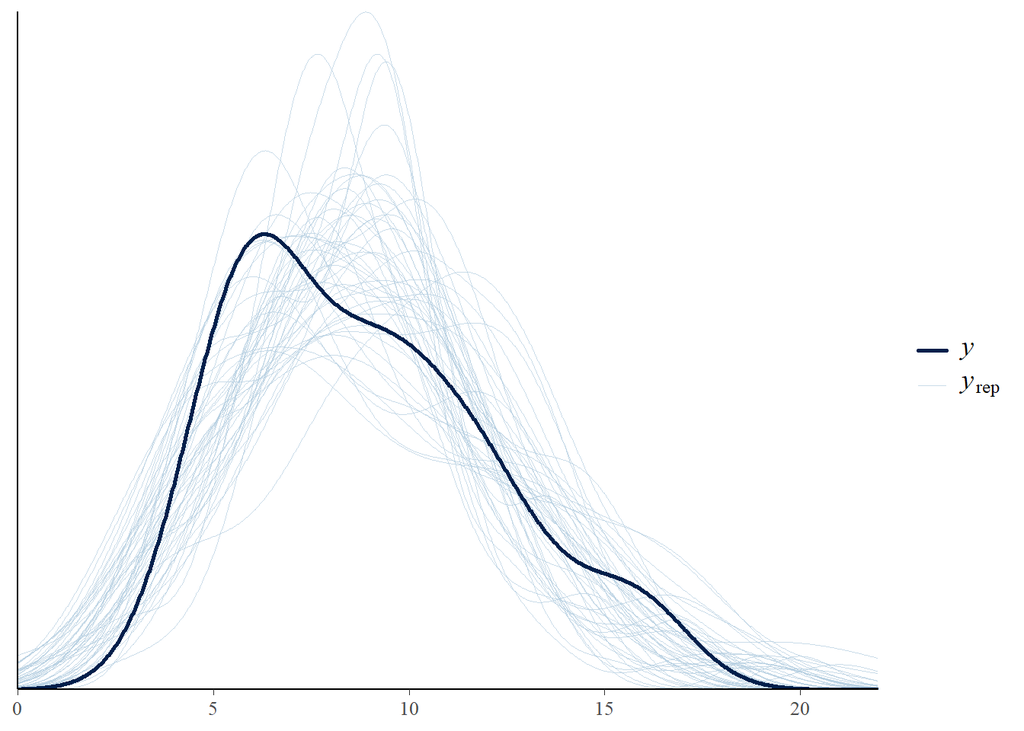

```r
mrep <- fit_5.6$draws("mp", format = "draws_matrix")

ppc_dens_overlay(
  y = stan_data$M,
  yrep = mrep[sample(nrow(df), 50), ]
)
```

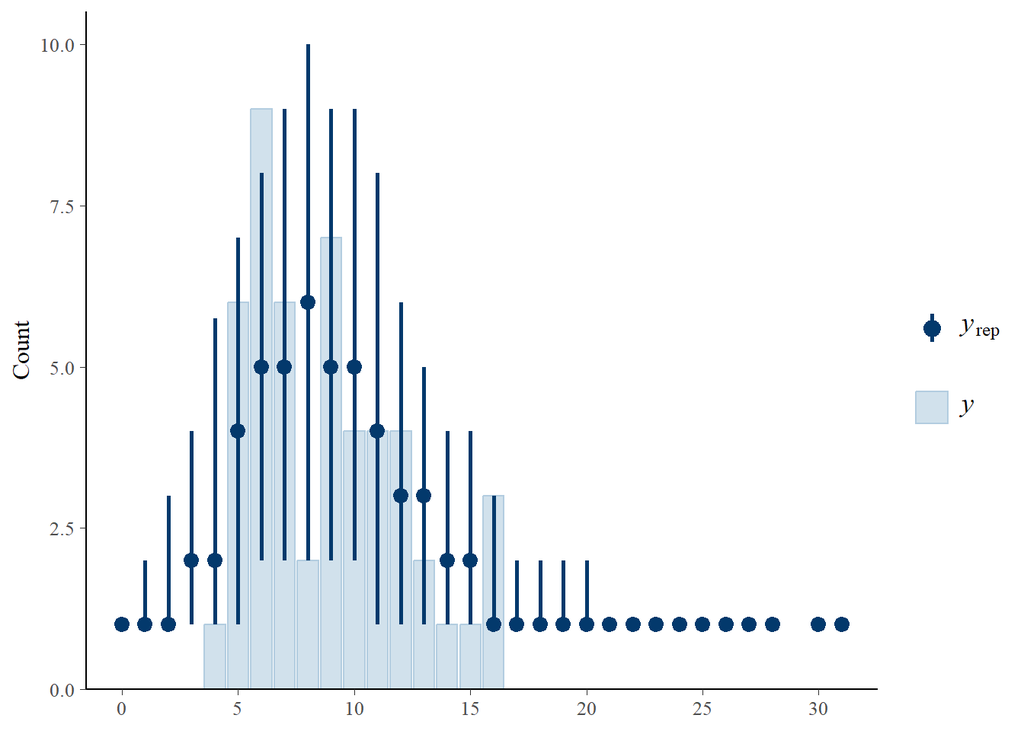

```r
ppc_bars(
  y = stan_data$M,
  yrep = mrep
)
```

### 5.6 Expression Using Matrix option

```r
df <- read_csv("https://raw.githubusercontent.com/MatsuuraKentaro/Bayesian_Statistical_Modeling_with_Stan_R_and_Python/refs/heads/master/chap05/input/data-shopping-4.csv")
```

Model Formula using Matrix

```stan
data{
  int N;
  int D;
  matrix[N,D] X;
  vector[N] Y;
}

parameters {
  vector[D] b;
  real<lower=0> sigma;
}

transformed parameters {
  vector[N] mu = X*b;
}

model {
Y[1:N] ~ normal(mu[1:N], sigma);
}
```

```r
X_mat <- df |>
  select(Sex, Income, X3, X4) |>
  as.matrix()

stan_data <- list(
  N = nrow(df),
  D = ncol(X_mat),
  X = X_mat,
  Y = df$Y
)

model_5.7 <- cmdstan_model("model/model5-7.stan")
fit_5.7 <- model_5.7$sample(
  data = stan_data,
  seed = 123,
  refresh = 1000
)
```

```
Running MCMC with 4 sequential chains...

Chain 1 Iteration:    1 / 2000 [  0%]  (Warmup)
Chain 1 Iteration: 1000 / 2000 [ 50%]  (Warmup)
Chain 1 Iteration: 1001 / 2000 [ 50%]  (Sampling)
Chain 1 Iteration: 2000 / 2000 [100%]  (Sampling)
Chain 1 finished in 0.8 seconds.
Chain 2 Iteration:    1 / 2000 [  0%]  (Warmup)
Chain 2 Iteration: 1000 / 2000 [ 50%]  (Warmup)
Chain 2 Iteration: 1001 / 2000 [ 50%]  (Sampling)
Chain 2 Iteration: 2000 / 2000 [100%]  (Sampling)
Chain 2 finished in 0.9 seconds.
Chain 3 Iteration:    1 / 2000 [  0%]  (Warmup)
Chain 3 Iteration: 1000 / 2000 [ 50%]  (Warmup)
Chain 3 Iteration: 1001 / 2000 [ 50%]  (Sampling)
Chain 3 Iteration: 2000 / 2000 [100%]  (Sampling)
Chain 3 finished in 0.8 seconds.
Chain 4 Iteration:    1 / 2000 [  0%]  (Warmup)
Chain 4 Iteration: 1000 / 2000 [ 50%]  (Warmup)
Chain 4 Iteration: 1001 / 2000 [ 50%]  (Sampling)
Chain 4 Iteration: 2000 / 2000 [100%]  (Sampling)
Chain 4 finished in 0.8 seconds.

All 4 chains finished successfully.
Mean chain execution time: 0.8 seconds.
Total execution time: 4.3 seconds.
```

```r
fit_5.7$summary()
```

```
# A tibble: 56 × 10
   variable      mean    median       sd     mad       q5     q95  rhat ess_bulk
   <chr>        <dbl>     <dbl>    <dbl>   <dbl>    <dbl>   <dbl> <dbl>    <dbl>
 1 lp__     124.      124.      1.60     1.45e+0  1.21e+2 1.26e+2  1.00    1539.
 2 b[1]       0.145     0.144   0.0134   1.32e-2  1.22e-1 1.67e-1  1.00    2845.
 3 b[2]       0.00588   0.00588 0.000192 1.89e-4  5.57e-3 6.19e-3  1.00    3194.
 4 b[3]      -0.00211  -0.00219 0.00769  7.52e-3 -1.47e-2 1.08e-2  1.00    2733.
 5 b[4]       0.0368    0.0368  0.0107   1.08e-2  1.93e-2 5.41e-2  1.00    2497.
 6 sigma      0.0486    0.0482  0.00521  5.02e-3  4.10e-2 5.80e-2  1.00    2140.
 7 mu[1]      0.546     0.546   0.0127   1.24e-2  5.25e-1 5.66e-1  1.00    3341.
 8 mu[2]      0.549     0.549   0.0106   1.08e-2  5.32e-1 5.67e-1  1.00    2939.
 9 mu[3]      0.607     0.607   0.0175   1.77e-2  5.77e-1 6.35e-1  1.00    3056.
10 mu[4]      0.643     0.643   0.0127   1.27e-2  6.22e-1 6.63e-1  1.00    2897.
# ℹ 46 more rows
# ℹ 1 more variable: ess_tail <dbl>
```